# Exploratory analysis of Sediment Toxicity Data : Metals

# Install Libraries

```r
library(readxl)
library(GGally)
library(maxLik)
```

# Load Basic Data

```r
sibfldnm <- 'Derived Data'
parent <- dirname(getwd())
sibling <- paste(parent,sibfldnm, sep = '/')
fn <- 'working.data.xls'

the.data <- read_excel(paste(sibling,fn, sep='/'),
    sheet = "Combined", col_types = c("skip",
        "text", "skip", "skip", "skip",
        "skip", "skip", "skip", "skip",
        "text", "text", "numeric", "text",
        "numeric", "text", "numeric", "numeric",
        "text", "text", "text", "skip",
        "skip", "skip", "skip", "skip",
        "numeric", "numeric", "skip", "skip",
        "skip", "skip", "skip", "skip",
        "skip")) %>%
  mutate(SAMPLE_ID = factor(SAMPLE_ID,
                            levels = c("CSP-1", "CSP-2", "CSP-3",
                                       "CSP-4", "CSP-5", "CSP-6",
                                       "CSP-7", "CSP-7D", "CSP-8",
                                       "CSP-9", "CSP-10", "CSP-11",
                                       "CSP-12", "CSS-13", "CSP-14",
                                       "CSS-15")))
```

# Chemical Parameters

```r
metals.names <- read_excel(paste(sibling,fn, sep='/'), sheet = "Metals", skip = 3) %>%
  select(1) %>%
  slice(1:8) #%>%
```

[output not shown]

```r
  #mutate(PARAMETER_NAME = substr(PARAMETER_NAME, 1, nchar(PARAMETER_NAME)-7))
(metals.names <- metals.names$PARAMETER_NAME)
```

```
[1] "ARSENIC, TOTAL"  "CADMIUM, TOTAL"  "CHROMIUM, TOTAL" "COPPER, TOTAL"
[5] "MERCURY, TOTAL"  "NICKEL, TOTAL"   "LEAD, TOTAL"     "ZINC, TOTAL"
```

# Extract Metals Data Only

We filter to selected parameters defined in a list of parameters. Notice the second and third filters, which remove QA/QC samples.

We have some duplicate samples (for CSP-6, CSP-15 - all measurements - CSP-10 - TOC data only - and CSP-9 - all observations EXCEPT TOC), so we want to calculate average values across multiple samples.

The following reads in data and assigns the value of the reporting limit to data that was below the detection limits. That cues up later steps that make different analytic assumptions.

We also need to strip the “, TOTAL” From the end of each metal name in sed.data and/or sed.data.long.

```r
metals.data.long <- the.data %>%
  filter (the.data$PARAMETER_NAME %in% metals.names) %>%
  mutate(PARAMETER_NAME = sub(', TOTAL', '', PARAMETER_NAME)) %>%
  filter(is.na(`%_RECOVERY`)) %>%
  filter(SAMPLE_ID != 'QC') %>%
  mutate(CONCENTRATION = ifelse(is.na(CONCENTRATION) & LAB_QUALIFIER == 'U',
                                REPORTING_LIMIT, CONCENTRATION)) %>%
  group_by(SAMPLE_ID, PARAMETER_NAME) %>%
  summarize(CONCENTRATION = mean(CONCENTRATION, na.rm=TRUE),
            censored = sum(LAB_QUALIFIER=='U', na.rm=TRUE))

metals.data <- metals.data.long %>%
  spread(key = PARAMETER_NAME, value = CONCENTRATION) %>%
  rowwise() %>%
  mutate(totmetals = sum(c(`ARSENIC`, `CADMIUM`,  `CHROMIUM`,
                           `COPPER`,`MERCURY`,  `NICKEL`, `LEAD`,
                           `ZINC`), na.rm = TRUE))
```

# We Have NO Non-detects

```r
any(metals.data.long$censored>0)
```

```
[1] FALSE
```

# Initial graphics

## Pairs Plot

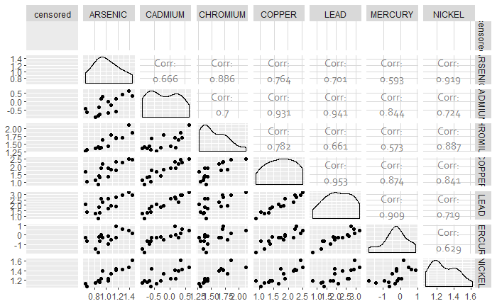

```r
ggpairs(log10(metals.data[2:9]))
```

So most metals appear highlty correlated. However in tihs simple view you need to be careful that you are not misinterpreting non-detects (which are corrlated accross parameters) with actual data.

## Metals by Plots

[figure not shown]

```r
tmp <- metals.data
tmp$SAMPLE_ID <- reorder(tmp$SAMPLE_ID, tmp$totmetals, mean, na.rm = TRUE)
#levels(tmp$SAMPLE_ID)

tmp <- tmp %>% gather(key = 'metal', value = 'Concentration', 3:10) %>%
  mutate(metals = factor(metal)) %>%
  mutate(metals = reorder(metal, Concentration, mean))


plt <- ggplot(tmp, aes(x=as.numeric(SAMPLE_ID), y = Concentration, color = metals)) +
  geom_line(lwd = 1) +
  scale_x_continuous(breaks = c(1:16-0.25), labels = levels(tmp$SAMPLE_ID),
                     minor_breaks = FALSE) +
  xlab('Site ID') +
  ylab('Log10 of Concentration (mg/kg)') +
  theme_minimal() +
  theme(axis.text.x = element_text(angle = 90, hjust = 1)) +
  theme(panel.grid = element_blank())
plt
```

## Plots By Metals

[figure not shown]

```r
tmp <- metals.data %>%
  select(-censored) %>%
  gather(key = 'Metal', value = 'Concentration', 2:9) %>%
  mutate(Metal = factor(Metal)) %>%
  mutate(Metal = reorder(Metal, Concentration, mean, na.rm=TRUE))

plt <- ggplot(tmp, aes(x=as.numeric(Metal), y=Concentration, color = SAMPLE_ID)) +
  ylab('Log10 of Concentration (ppm)') +
  scale_x_continuous(breaks = c(1:8-0.25), labels = levels(tmp$Metal),
                     minor_breaks = FALSE) +
  theme_minimal() +
  theme(axis.text.x = element_text(angle = 90, hjust = 1)) +
  theme(panel.grid = element_blank())
plt
```

Note that levels of metal tend to be correlated – High in one implies high in several.

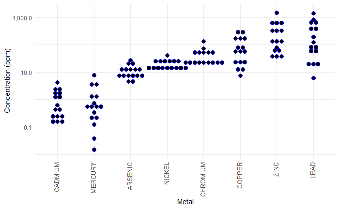

```r
plt <- ggplot(tmp, aes(x=Metal, y=Concentration)) +
  # primary geom can be geom_boxplot,  geom_violin", Geom_point, or geom_dotplot
  # Combinations are also interesting. Note that I  turned off  display of
  # outliers in the boxlot code, which is appropriate if you overlay points.

  #geom_boxplot(outlier.shape = NA) +
  #geom_violin() +
  #geom_point(size = 1, alpha = 0.5) +

  geom_dotplot(binaxis='y', stackdir = "center",
                dotsize = 1, color = 'blue1') +

  theme_minimal() +
  theme(axis.text.x = element_text(size = 10, hjust= 1, vjust = 0.25, angle = 90)) +
  scale_y_log10(labels = scales::comma) +
  xlab('Metal')+ ylab('Concentration (ppm)')
plt
```

```r
NA
NA
```

## Load Screening Values Data

The names in the screening values table have to exactly match the order of levels for the Chemicals in the metals data if we want the final graphics to plot them in order.

```r
fn= "Marine Sediment Screening Values simplified.xlsx"
 SQUIRTS <- read_excel(paste(sibling,fn, sep = '/')) %>%
   select(1:8) %>%
   filter(Chemical %in% names(metals.data)) %>%
   mutate(Chemical = factor(Chemical)) #%>%
   #filter(! is.na(Chemical))

 SQUIRTS.LONG <- SQUIRTS %>%
   gather(key = 'type', value = 'value', -Chemical) %>%
   filter(type %in% c('ERL','ERM'))
```

### Convert to a look-up table

Now, I convert the SQIRTS data to a look-up table, by converting the Chemical column to row names. While this is discouraged in the tidyverse, it is slightly more convenient to implement a look-up this way. Note that all this accomplishes is to slightly simplify how I specify which row(s) I’m interested in. The following creates an indicator that shows whether specific measurements are above certain screening levels.

our interest here focuses on the “Effects Range Low” and “Effects Range Medium” screening criteria. WE focus on those only because we have used them in the past.

```r
lookup <- SQUIRTS %>%
  column_to_rownames(var = 'Chemical')

metals.data.long <- metals.data.long %>%
  mutate(ERL = lookup[PARAMETER_NAME, 'ERL']) %>%
  mutate(ERM = lookup[PARAMETER_NAME, 'ERM']) %>%
  mutate(LVL = factor(ifelse(is.na(ERL), 'N/A',
                             ifelse(CONCENTRATION<=ERL, 'Value <= ERL',
                                   ifelse(CONCENTRATION<=ERM,
                                          'ERL < Value <= ERM','ERM < Value'))),
                      levels = c('N/A','Value <= ERL',
                                 'ERL < Value <= ERM','ERM < Value')))
```

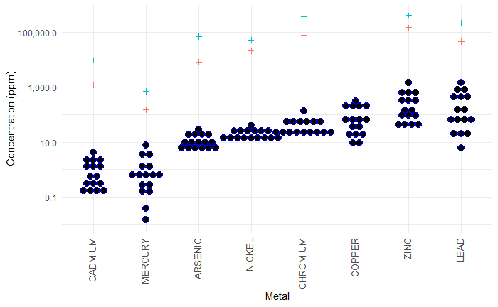

```r
plt +
  geom_point(data = SQUIRTS.LONG,
             mapping = aes(x=Chemical, y=value, color = type ), shape = 3)+
  theme(legend.position = 'None')
```

So, absolutely consistently, metals levels are below relevant screening levels by an order of magnitude or more.

# Conclusion

All Metals are below Levels of Concern, by about an order of magnitude. So probably not worth showing on a graphic. Intreest here may be increased if plots with high metals are also high in other contaminants.